# Exploration of Loan Data from Prosper

## Investigation Overview

I chose the Prosper Loan Data to investigate on the structure of loans. I will investigate the relationship between loan pricing, rating and other variables.

## Dataset Overview

In the dataset are 113937 loan entries. The loan data contains 81 columns, which is a significant amount of features assosicated with each loan.

Most variables are numeric (float or int) like LoanOriginalAmount, BorrowerRate etc. A significant amount are ordinal values like the ProsperRating (lowest - 0 - N/A, 1 - HR, 2 - E, 3 - D, 4 - C, 5 - B, 6 - A, 7 - AA - highest) or the ProsperScore (from 1-10, with 10 being the highest and 1 the lowest risk score).

Some of the numeric values represent categorical data, e.g ListingCategory (numeric): 0 - Not Available, 1 - Debt Consolidation, 2 - Home Improvement, 3 - Business, 4 - Personal Loan, 5 - Student Use, 6 - Auto, 7- Other, 8 - Baby&Adoption, 9 - Boat, 10 - Cosmetic Procedure, 11 - Engagement Ring, 12 - Green Loans, 13 - Household Expenses, 14 - Large Purchases, 15 - Medical/Dental, 16 - Motorcycle, 17 - RV, 18 - Taxes, 19 - Vacation, 20 - Wedding Loans.

## Distribution of Loan Amounts

Majority of the loans are between 1000 and 15000 USD with a slightly right skewed distribution, however there are clearly spikes at 4000, 10000 and 15000 USD.

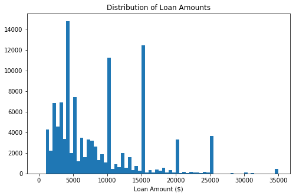

```python
binsize = 500
bins = np.arange(0, df['LoanOriginalAmount'].max()+binsize, binsize)

plt.figure(figsize = [8, 5])
plt.hist(data = df, x = 'LoanOriginalAmount', bins=bins);
plt.xlabel('Loan Amount ($)');
plt.title('Distribution of Loan Amounts');
plt.show();
```

## Distribution of Interest Rates

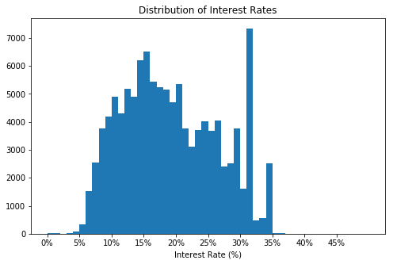

```python
binsize = 0.01
bins = np.arange(0, df['BorrowerRate'].max()+binsize, binsize)
plt.figure(figsize = [8, 5])
plt.hist(data = df, x = 'BorrowerRate', bins = bins)
tick_props = np.arange(0, 0.5, 0.05)
tick_names = ['{:0.0f}%'.format(v*100) for v in tick_props]
plt.xticks(tick_props, tick_names)
plt.xlabel('Interest Rate (%)');
plt.title('Distribution of Interest Rates');
plt.show()
```

## Distribution of Rating Categories

The rating categories are normal distributed. The gap between second-best (6) and best rating (7), however, is significant.

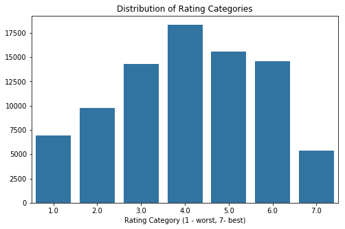

```python
plt.figure(figsize = [8, 5])
sb.countplot(data = df, x = 'ProsperRating (numeric)', color = base_color);
plt.xlabel('Rating Category (1 - worst, 7- best)');
plt.ylabel('');
plt.title('Distribution of Rating Categories');
plt.show()
```

## Interest Rate vs Rating

The interest rate decreases step by step with every rating category increase. The worst rating category (1) shows a mean interest rate of 32%. The best rating category (7) shows a mean interest rate of 8%.

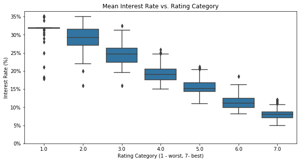

```python
plt.figure(figsize = [10, 5])
sb.boxplot(data = df_small, x = 'ProsperRating (numeric)', y = 'BorrowerRate', color = base_color);
tick_props = np.arange(0, 0.4, 0.05)
tick_names = ['{:0.0f}%'.format(v*100) for v in tick_props]
plt.yticks(tick_props, tick_names)
plt.ylabel('Interest Rate (%)');
plt.xlabel('Rating Category (1 - worst, 7- best)');
plt.title('Mean Interest Rate vs. Rating Category');
```

## Interest Rate vs Loan Amount vs. Rating

The correlation between interest rate and loan amount is negative and highly dependent on the rating category. There is supposed to be a causality, as banks should be unlikely giving big loans to customers with bad ratings, so in turn customers with better rating receive bigger loans and the better ratings lead to lower interest rates for these loans in general. Additionally, there are almost no rates below 5% (supposedly a floor to cover administartive costs).

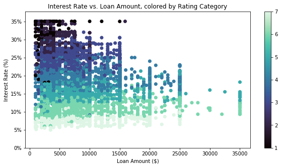

```python
plt.figure(figsize = [10, 5])
plt.scatter(data = df_med, x = 'LoanOriginalAmount', y = 'BorrowerRate', c = 'ProsperRating (numeric)',
            cmap = 'mako', linewidths = 1);
plt.colorbar();
tick_props = np.arange(0, 0.4, 0.05)
tick_names = ['{:0.0f}%'.format(v*100) for v in tick_props]
plt.yticks(tick_props, tick_names)
plt.ylabel('Interest Rate (%)');
plt.xlabel('Loan Amount ($)');
plt.title('Interest Rate vs. Loan Amount, colored by Rating Category');
```

## Further Influential Factors on Interest Rate

Finally, the interest rate also varies from month to month. The mean interest rate was the highest from November to January. Consequently, the best month to get a loan is April.

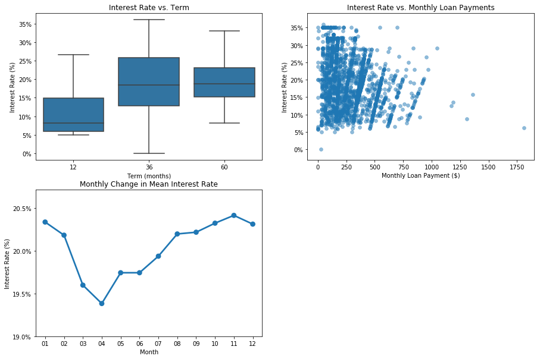

```python
plt.figure(figsize = [15, 10]);
plt.subplot(2, 2, 1)
sb.boxplot(data = df_small, x = 'Term', y = 'BorrowerRate', color = base_color);
tick_props = np.arange(0, 0.4, 0.05)
tick_names = ['{:0.0f}%'.format(v*100) for v in tick_props]
plt.yticks(tick_props, tick_names)
plt.ylabel('Interest Rate (%)');
plt.xlabel('Term (months)');
plt.title('Interest Rate vs. Term');

plt.subplot(2, 2, 2)
plt.scatter(data = df_small, x = 'MonthlyLoanPayment', y='BorrowerRate', color = base_color, alpha=0.5, linewidths=0.5);
tick_props = np.arange(0, 0.4, 0.05)
tick_names = ['{:0.0f}%'.format(v*100) for v in tick_props]
plt.yticks(tick_props, tick_names)
plt.xlabel('Monthly Loan Payment ($)');
plt.ylabel('Interest Rate (%)');
plt.title('Interest Rate vs. Monthly Loan Payments');

plt.subplot(2, 2, 3)
sb.pointplot(data = df3, x = 'ClosedDate', y = 'BorrowerRate', errwidth = 0);
tick_props = np.arange(0.19, 0.21, 0.005)
tick_names = ['{}%'.format(v*100) for v in tick_props]
plt.yticks(tick_props, tick_names)
plt.ylabel('Interest Rate (%)');
plt.xlabel('Month');
plt.title('Monthly Change in Mean Interest Rate');
```

## Influencial Factors on Rating Category Part I

An interesting fact is that the rating gives priority to debt ratio over delinquencies, as the category with the lowest rating (1) had lower deliquiency rates compared to the second lowest deliqency rates.

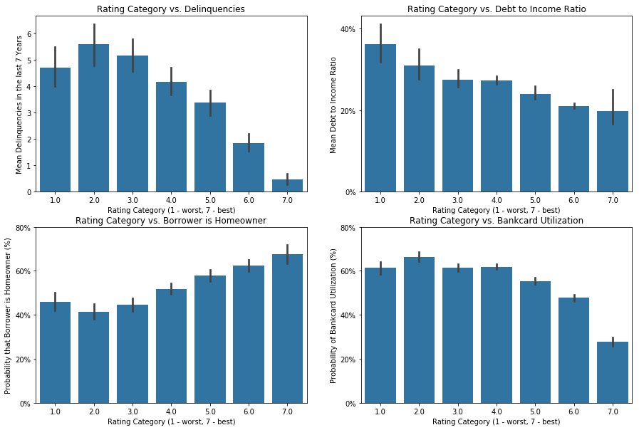

```python
plt.figure(figsize = [15, 10]);
plt.subplot(2, 2, 1)
sb.barplot(data = df_med, x = 'ProsperRating (numeric)', y = 'DelinquenciesLast7Years', color = base_color);
plt.ylabel('Mean Delinquencies in the last 7 Years');
plt.xlabel('Rating Category (1 - worst, 7 - best)');
plt.title('Rating Category vs. Delinquencies');

plt.subplot(2, 2, 2)
sb.barplot(data = df_med, x = 'ProsperRating (numeric)', y = 'DebtToIncomeRatio', color = base_color);
plt.xlabel('Rating Category (1 - worst, 7 - best)');
tick_props = np.arange(0, 0.6, 0.2)
tick_names = ['{:0.0f}%'.format(v*100) for v in tick_props]
plt.yticks(tick_props, tick_names)
plt.ylabel('Mean Debt to Income Ratio');
plt.title('Rating Category vs. Debt to Income Ratio');

plt.subplot(2, 2, 3)
sb.barplot(data = df_med, x = 'ProsperRating (numeric)', y='IsBorrowerHomeowner', color = base_color);
plt.xlabel('Rating Category (1 - worst, 7 - best)');
tick_props = np.arange(0, 1, 0.2)
tick_names = ['{:0.0f}%'.format(v*100) for v in tick_props]
plt.yticks(tick_props, tick_names)
plt.ylabel('Probability that Borrower is Homeowner (%)');
plt.title('Rating Category vs. Borrower is Homeowner');

plt.subplot(2, 2, 4)
sb.barplot(data = df_med, x = 'ProsperRating (numeric)', y = 'BankcardUtilization', color = base_color);
plt.xlabel('Rating Category (1 - worst, 7 - best)');
tick_props = np.arange(0, 1, 0.2)
tick_names = ['{:0.0f}%'.format(v*100) for v in tick_props]
plt.yticks(tick_props, tick_names)
plt.ylabel('Probability of Bankcard Utilization (%)');
plt.title('Rating Category vs. Bankcard Utilization');
```

## Influencial Factors on Rating Category Part II

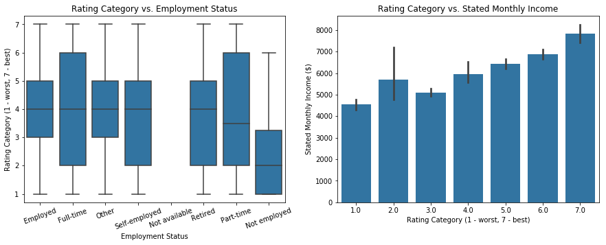

```python
plt.figure(figsize = [15, 5]);
plt.subplot(1, 2, 1)
sb.boxplot(data = df_med, x = 'EmploymentStatus', y='ProsperRating (numeric)', color = base_color);
plt.ylabel('Rating Category (1 - worst, 7 - best)');
plt.xlabel('Employment Status');
plt.xticks(rotation=20);
plt.title('Rating Category vs. Employment Status');

plt.subplot(1, 2, 2)
sb.barplot(data = df_med, x = 'ProsperRating (numeric)', y = 'StatedMonthlyIncome', color = base_color);
plt.xlabel('Rating Category (1 - worst, 7 - best)');
plt.ylabel('Stated Monthly Income ($)');
plt.title('Rating Category vs. Stated Monthly Income');
```

## Development of Loan Amounts and Interest Rate over Years

From 2005 to 2009, the mean loan amounts and also the mean interest rates significantly increased. The mean loan amount in 2005 was approx. 2500 USD, in 2014, however, the mean loan amount was approx. 8000 USD. The mean interest rate in 2005 was approx. 9%, and in 2014 it rose up to approx. 20%.

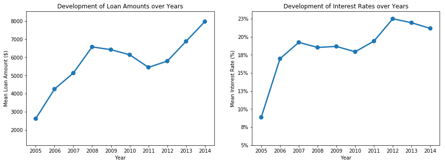

```python
plt.figure(figsize = [15, 5])
plt.subplot(1, 2, 1)
sb.pointplot(data = df2, x = 'ClosedDate', y = 'LoanOriginalAmount', errwidth = 0);
plt.ylabel('Mean Loan Amount ($)');
plt.xlabel('Year');
plt.title('Development of Loan Amounts over Years');

plt.subplot(1, 2, 2)
sb.pointplot(data = df2, x = 'ClosedDate', y = 'BorrowerRate', errwidth = 0);
tick_props = np.arange(0.05, 0.25, 0.025)
tick_names = ['{:0.0f}%'.format(v*100) for v in tick_props]
plt.yticks(tick_props, tick_names)
plt.ylabel('Mean Interest Rate (%)');
plt.xlabel('Year');
plt.title('Development of Interest Rates over Years');
```